# Nitinat escapement 2025 (PRELIM)

## 5.4 Snorkel, river seine & swim-in counts

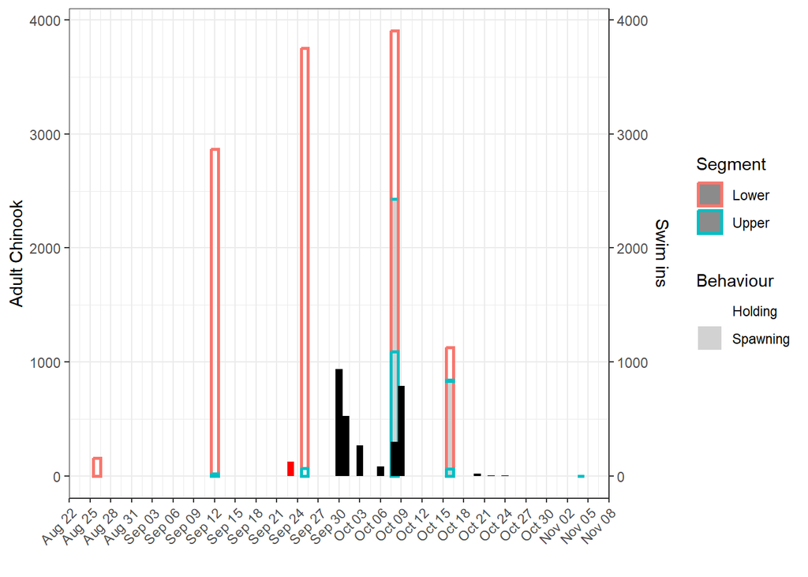

Figure: Observed adult Chinook counts (coloured bars) and swim-ins (black bars). Adult bar fill colour indicates behaviour (spawning=gray, holding=white), bar outline colour indicates river segment (lower=pink, upper=blue). If a solid red bar is present, this indicates a river beach seine event for broodstock collection.

The total number collected from river beach seining is: 124, of which 118 were adults.

## 5.5 Tributaries (River and Lake)

The following section is largely to help with determining whether Nitinat River trib counts (Parker, Worthless, Jasper, NoName, Little Nitinat) need to be in addition to the mainstem count, or if we think the fish that ended up in the tribs were captured in the mainstem swims (so don’t need to be in addition to, and should be subtracted from the mainstem count).

In some years there aren’t tributary surveys, so this may not apply.

| date | NAME | ad_live | exp_ad_livve | dead_adults | jk_live | jk_dead |
| --- | --- | --- | --- | --- | --- | --- |
| 2025-04-30 | HOBITON CREEK | 0 | 0 | 0 | 0 | 0 |
| 2025-05-28 | HOBITON CREEK | 0 | 0 | 0 | 0 | 0 |
| 2025-06-17 | HOBITON CREEK | 0 | 0 | 0 | 0 | 0 |
| 2025-09-22 | KLANAWA RIVER | 0 | 0 | 0 | 0 | 0 |
| 2025-10-07 | HOBITON CREEK | 6 | 7 | 0 | 5 | 0 |
| 2025-10-10 | KLANAWA RIVER | 37 | 37 | 0 | 0 | 0 |
| 2025-10-21 | LITTLE NITINAT RIVER | 0 | 0 | 0 | 0 | 0 |
| 2025-10-29 | CAMPUS CREEK | 0 | 0 | 0 | 0 | 0 |
| 2025-11-12 | KLANAWA RIVER | 0 | 0 | 0 | 0 | 0 |

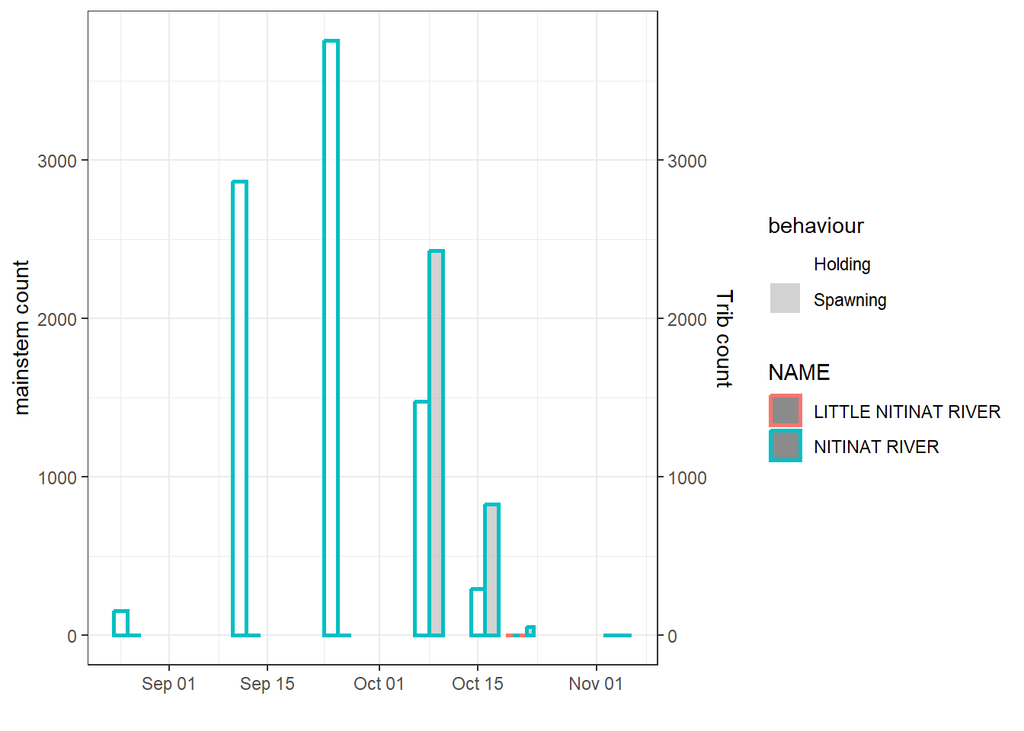

## 5.6 AUC assessments

The information below is meant to assist with determining if AUC is an appropriate method, and whether to include/exclude certain surveys.

Table: AUC math for systems receiving AUC estimate in 2025

```
## # A tibble: 7 × 13
##   WatershedCode            Year ShortSpecies DateRange NoOfDays RawAdultFishDays
##   <chr>                   <dbl> <chr>        <chr>        <dbl>            <dbl>
## 1 930-071700-00000-00000…  2025 CN           2025/08/…       25            1950
## 2 930-071700-00000-00000…  2025 CN           2025/08/…       17           25696.
## 3 930-071700-00000-00000…  2025 CN           2025/09/…       13           43050.
## 4 930-071700-00000-00000…  2025 CN           2025/09/…       13           49803
## 5 930-071700-00000-00000…  2025 CN           2025/10/…        8           20128
## 6 930-071700-00000-00000…  2025 CN           2025/10/…       19               0
## 7 930-071700-00000-00000…  2025 CN           2025/11/…        1               0
## # ℹ 7 more variables: RawJackFishDays <dbl>, ExpAdultFishDays <dbl>,
## #   ExpJackFishDays <dbl>, AREA <chr>, n <int>, SystemName <chr>, method <chr>
```

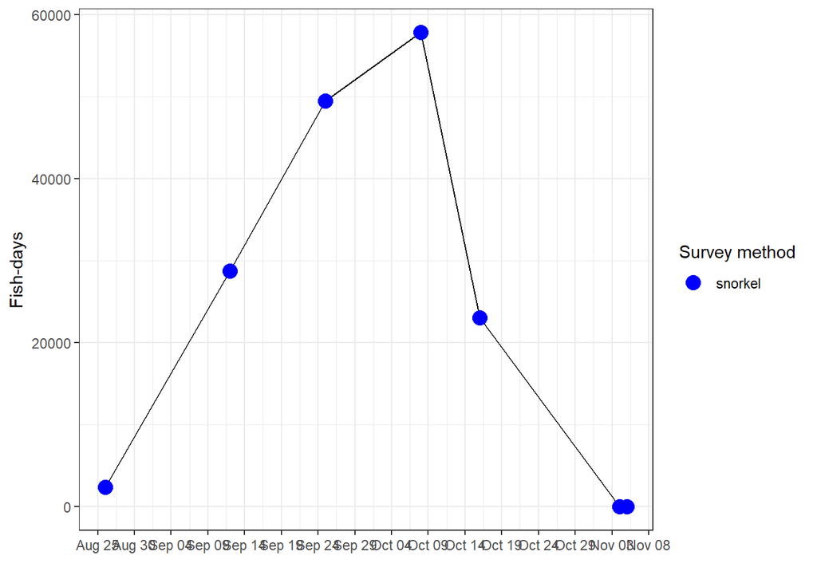

Figure: AUC curve for Nitinat mainstem Chinook.

## 5.7 Area 21-22 preliminary escapement estimates (AUC/PL+D)

Table: Escapement estimate options (AUC/PL+D) for each system.

| Year | SystemName | AREA | ShortSpecies | StartingZeroDate | EndingZeroDate | AdultShortResidenceTime | AdultMidResidenceTime_R | AdultLongResidenceTime | JackShortResidenceTime | JackMidResidenceTime_R | JackLongResidenceTime | AUCTotalDays | AdultExpAUCLowValue | AdultExpAUCMidValue_R | AdultExpAUCHighValue | JackExpAUCLowValue | JackExpAUCMidValue_R | JackExpAUCHighValue | AdultExpPLD | JackExpPLD | FinalAdultEstimate | AdultRemovalsReco | FinalJackEstimate | JackRemovalsReco | AdultRemovalsIncluded | JackRemovalsIncluded | EnumerationClass | IsFinal |
| --- | --- | --- | --- | --- | --- | --- | --- | --- | --- | --- | --- | --- | --- | --- | --- | --- | --- | --- | --- | --- | --- | --- | --- | --- | --- | --- | --- | --- |
| 2025 | Nitinat River, Nitinat Lake | 22 | CN | 2025-08-01 | 2025-11-04 | 15 | 20 | 25 | 15 | 20 | 25 | 96 | 6457 | 8071 | 10762 | 352 | 440 | 587 | 5245 | 372 | 5500 | 2571 | 221 | 219 | TRUE | TRUE | 3 | FALSE |
|  | Klanawa River | 21 |  | 2025-09-01 | 2025-11-15 | 15 | 20 | 25 | 15 | 20 | 25 | 75 | 27 | 33 | 44 | 0 | 0 | 0 | 74 | 0 | 74 | 0 | 0 | 0 | FALSE | FALSE | 6 | FALSE |

### 5.7.1 Estimate decision:

Prior to this RMarkdown script I had already decided to omit the heli survey this year as it was not timed well for Chinook, and the counting was difficult in cases where Chinook might be post-spawn (pools, edges). This is reflected in most, if not all of the graphs with the survey omitted.

Opted for the middle-range SL for AUC for the preliminary estimate as the run timing was normal, despite the lake turnover events, low early water, and overall odd year for Chum arrival (late). Chinook entered the system early Sept which may have been a bit late, but was not linked to much of a rain event. Chinook already peaked in the system by the major rains, and spawn/die-off timing was relatively normal and predictable. No tributaries to account for this year.

Therefore, the final estimate for adult Chinook should be 8071 minus 2689 swim-ins, plus 118 seined fish, **resulting in** 5500 **adults**

**and**

440 minus 225 swim-ins, plus 6 seined fish, **resulting in** 221 **jacks.**

Note this year may be a low estimate due to two lake turnover events: September 17 and October 14. On the Sept 17th event, the hatchery lost ~3000 Chinook broodstock that were being held in the lake pens. There was speculation that fish in the lake may have been able to swim away and avoid the low oxygen conditions, while those stuck in the pens died. However, the extent of the die off from both events is unknown. Hatchery staff reported the lake smelled like rotten eggs on Oct 14 as well (presumably due to anoxic layer coming to surface). The early event would have impacted Chinook more, while the later event would have impacted Chum more (if there were impacts).

## 5.8 2025 compared to historical run timing and abundances

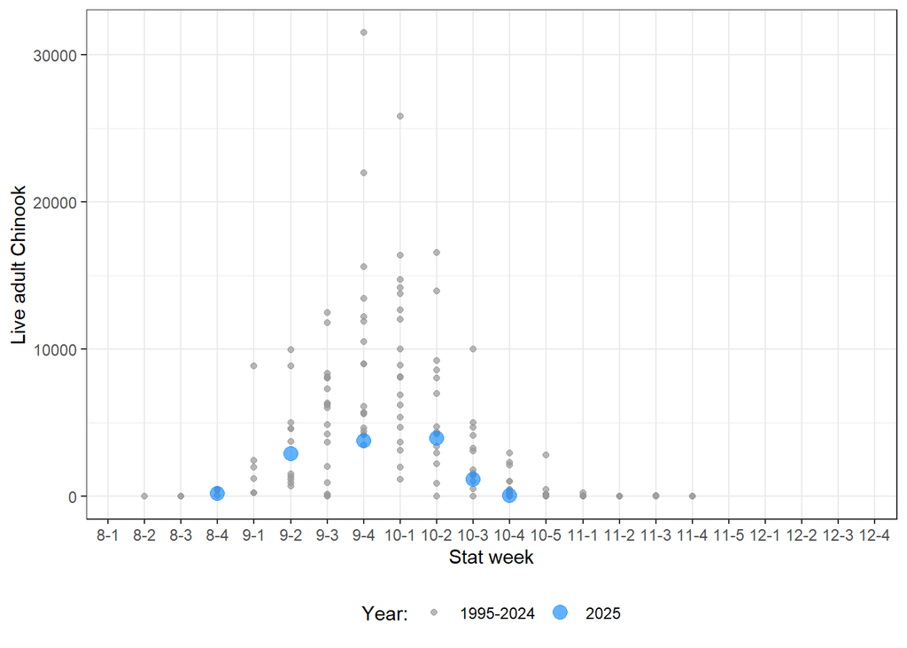

Figure: Raw swim counts (blue) from this year compared to historical raw swim counts. Stat weeks indicate the month (8=August, 12=December) and week of momth (1=first week, 2=2nd week, etc.), e.g., 81=First week of August, 91=First week of September, etc.

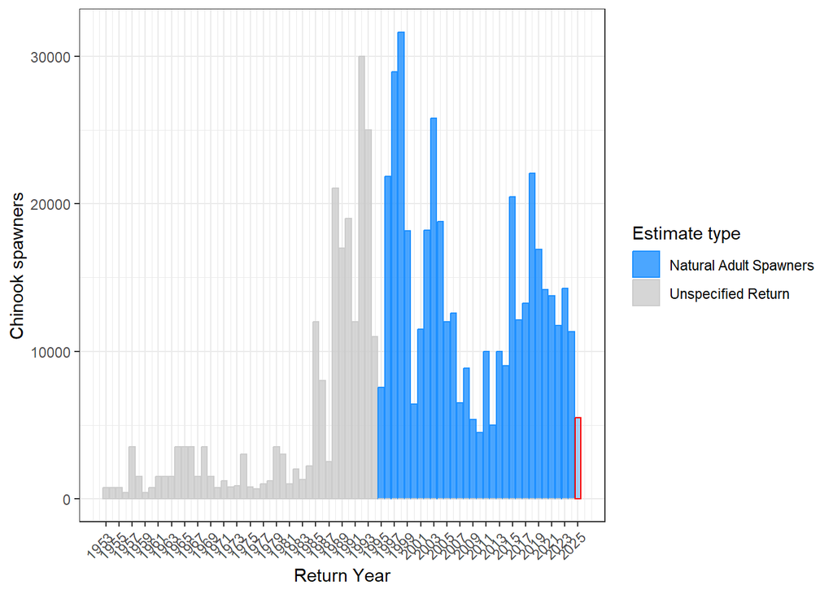

Figure: 2025 preliminary adult Chinook escapement estimate (red outline) relative to historical adult (blue) and unspecified (gray) escapement estimates.

# 6 **Pink**

No consistent WCVI pink runs.

## 6.1 Area 21-22 raw vs expanded counts

Counts are expanded for both % population surveyed and/or observer efficiency, depending on survey conditions.

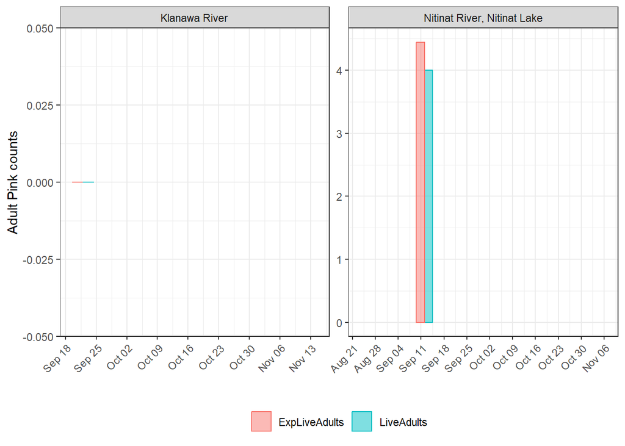

## 6.2 Area 21-22 preliminary escapement estimates

Table: Escapement estimates for each system.

| Year | SystemName | AREA | ShortSpecies | StartingZeroDate | EndingZeroDate | AdultShortResidenceTime | AdultMidResidenceTime_R | AdultLongResidenceTime | JackShortResidenceTime | JackMidResidenceTime_R | JackLongResidenceTime | AUCTotalDays | AdultExpAUCLowValue | AdultExpAUCMidValue_R | AdultExpAUCHighValue | JackExpAUCLowValue | JackExpAUCMidValue_R | JackExpAUCHighValue | AdultExpPLD | JackExpPLD | FinalAdultEstimate | AdultRemovalsReco | FinalJackEstimate | JackRemovalsReco | AdultRemovalsIncluded | JackRemovalsIncluded | EnumerationClass | IsFinal |
| --- | --- | --- | --- | --- | --- | --- | --- | --- | --- | --- | --- | --- | --- | --- | --- | --- | --- | --- | --- | --- | --- | --- | --- | --- | --- | --- | --- | --- |
| 2025 | Nitinat River, Nitinat Lake | 22 | PK | 2025-09-01 | 2025-11-15 | 15 | 20 | 25 | 15 | 20 | 25 | 82 | 2 | 2 | 3 | 0 | 0 | 0 | 4 | 0 | 4 | 0 | 0 | 0 | FALSE | FALSE | 4 | TRUE |
|  | Klanawa River | 21 |  | 2025-09-01 | 2025-11-15 | 15 | 20 | 25 | 15 | 20 | 25 | 75 | 0 | 0 | 0 | 0 | 0 | 0 | 0 | 0 | 0 | 0 | 0 | 0 | FALSE | FALSE | 6 | FALSE |

### 6.2.1 Estimate decision:

PL+D wherever seen.

## 6.3 2025 compared to historical escapement

[figure not shown]